# Meal Plan Recommendation

Meal plan recommendation system that uses content-based filtering to recommend meals based on dietary restrictions and preferences.This system aims to promote healthier eating habits by offering personalized meal options that adhere to user-specified dietary needs. The solution will be used in a website application. This application intends to build an unsupervised learning model from unlabelled data.

# Reading the data

```python
import pandas as pd
import matplotlib.pyplot as plt
```

```python
data=pd.read_csv('Data/recipes.csv')
data.head()
```

|  | RecipeId | Name | AuthorId | AuthorName | CookTime | PrepTime | TotalTime | DatePublished | Description | Images | ... | SaturatedFatContent | CholesterolContent | SodiumContent | CarbohydrateContent | FiberContent | SugarContent | ProteinContent | RecipeServings | RecipeYield | RecipeInstructions |
| --- | --- | --- | --- | --- | --- | --- | --- | --- | --- | --- | --- | --- | --- | --- | --- | --- | --- | --- | --- | --- | --- |
| 0 | 38 | Low-Fat Berry Blue Frozen Dessert | 1533 | Dancer | PT24H | PT45M | PT24H45M | 1999-08-09T21:46:00Z | Make and share this Low-Fat Berry Blue Frozen ... | c("https://img.sndimg.com/food/image/upload/w_... | ... | 1.3 | 8.0 | 29.8 | 37.1 | 3.6 | 30.2 | 3.2 | 4.0 | NaN | c("Toss 2 cups berries with sugar.", "Let stan... |
| 1 | 39 | Biryani | 1567 | elly9812 | PT25M | PT4H | PT4H25M | 1999-08-29T13:12:00Z | Make and share this Biryani recipe from Food.com. | c("https://img.sndimg.com/food/image/upload/w_... | ... | 16.6 | 372.8 | 368.4 | 84.4 | 9.0 | 20.4 | 63.4 | 6.0 | NaN | c("Soak saffron in warm milk for 5 minutes and... |
| 2 | 40 | Best Lemonade | 1566 | Stephen Little | PT5M | PT30M | PT35M | 1999-09-05T19:52:00Z | This is from one of my first Good House Keepi... | c("https://img.sndimg.com/food/image/upload/w_... | ... | 0.0 | 0.0 | 1.8 | 81.5 | 0.4 | 77.2 | 0.3 | 4.0 | NaN | c("Into a 1 quart Jar with tight fitting lid, ... |
| 3 | 41 | Carina's Tofu-Vegetable Kebabs | 1586 | Cyclopz | PT20M | PT24H | PT24H20M | 1999-09-03T14:54:00Z | This dish is best prepared a day in advance to... | c("https://img.sndimg.com/food/image/upload/w_... | ... | 3.8 | 0.0 | 1558.6 | 64.2 | 17.3 | 32.1 | 29.3 | 2.0 | 4 kebabs | c("Drain the tofu, carefully squeezing out exc... |
| 4 | 42 | Cabbage Soup | 1538 | Duckie067 | PT30M | PT20M | PT50M | 1999-09-19T06:19:00Z | Make and share this Cabbage Soup recipe from F... | "https://img.sndimg.com/food/image/upload/w_55... | ... | 0.1 | 0.0 | 959.3 | 25.1 | 4.8 | 17.7 | 4.3 | 4.0 | NaN | c("Mix everything together and bring to a boil... |

5 rows × 28 columns

```python
data.info()
```

```
<class 'pandas.core.frame.DataFrame'>
RangeIndex: 522517 entries, 0 to 522516
Data columns (total 28 columns):
 #   Column                      Non-Null Count   Dtype
---  ------                      --------------   -----
 0   RecipeId                    522517 non-null  int64
 1   Name                        522517 non-null  object
 2   AuthorId                    522517 non-null  int64
 3   AuthorName                  522517 non-null  object
 4   CookTime                    439972 non-null  object
 5   PrepTime                    522517 non-null  object
 6   TotalTime                   522517 non-null  object
 7   DatePublished               522517 non-null  object
 8   Description                 522512 non-null  object
 9   Images                      522516 non-null  object
```

[output cut: 20 more lines]

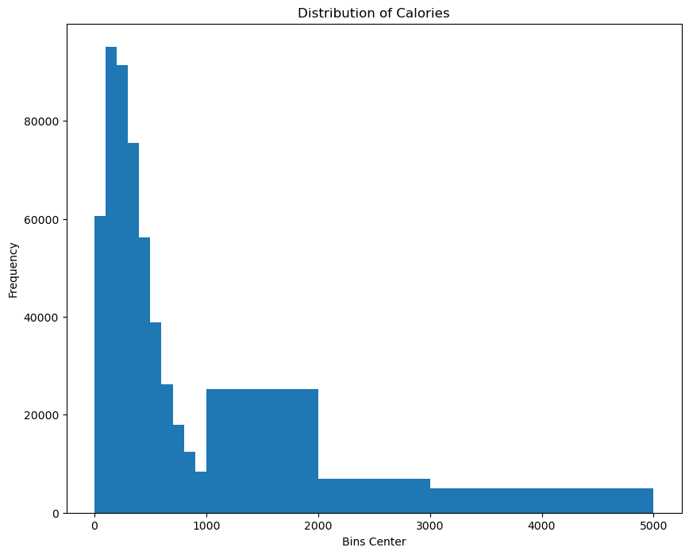

```python
fig, ax = plt.subplots(figsize=(10, 8))
plt.title('Distribution of Calories')
plt.ylabel('Frequency')
plt.xlabel('Bins Center')
ax.hist(data.Calories.to_numpy(),bins=[0,100,200,300,400,500,600,700,800,900,1000,1000,2000,3000,5000],linewidth=0.5)
plt.show()
```

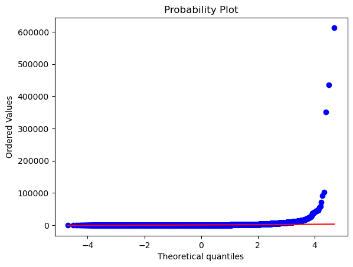

```python
import pylab
import scipy.stats as stats
stats.probplot(data.Calories.to_numpy(), dist="norm", plot=pylab)
pylab.show()
```

The plot shows a significant deviation from the straight line, indicating that the Calories data does not follow a normal distribution.The plot indicates positive skewness, as the data points curve upwards away from the line at higher quantiles. This suggests that there are a few data points with much higher calorie values than the rest.

# Preparing Data

Selecting the columns I am interested in order to build a model that takes into account the recipes nutritional characteristics.

```python
dataset=data.copy()
columns=['RecipeId','Name','CookTime','PrepTime','TotalTime','RecipeIngredientParts','Calories','FatContent','SaturatedFatContent','CholesterolContent','SodiumContent','CarbohydrateContent','FiberContent','SugarContent','ProteinContent','RecipeInstructions']
dataset=dataset[columns]
```

Setting max values to the parameters the user will be able to set for the recommendation of meals

```python
max_Calories=2000
max_daily_fat=100
max_daily_Saturatedfat=13
max_daily_Cholesterol=300
max_daily_Sodium=2300
max_daily_Carbohydrate=325
max_daily_Fiber=40
max_daily_Sugar=40
max_daily_Protein=200
max_list=[max_Calories,max_daily_fat,max_daily_Saturatedfat,max_daily_Cholesterol,max_daily_Sodium,max_daily_Carbohydrate,max_daily_Fiber,max_daily_Sugar,max_daily_Protein]
```

```python
extracted_data=dataset.copy()
for column,maximum in zip(extracted_data.columns[6:15],max_list):
    extracted_data=extracted_data[extracted_data[column]<maximum]
```

```python
extracted_data.info()
```

```
<class 'pandas.core.frame.DataFrame'>
Int64Index: 375703 entries, 0 to 522515
Data columns (total 16 columns):
 #   Column                 Non-Null Count   Dtype
---  ------                 --------------   -----
 0   RecipeId               375703 non-null  int64
 1   Name                   375703 non-null  object
 2   CookTime               313207 non-null  object
 3   PrepTime               375703 non-null  object
 4   TotalTime              375703 non-null  object
 5   RecipeIngredientParts  375703 non-null  object
 6   Calories               375703 non-null  float64
 7   FatContent             375703 non-null  float64
 8   SaturatedFatContent    375703 non-null  float64
 9   CholesterolContent     375703 non-null  float64
 10  SodiumContent          375703 non-null  float64
 11  CarbohydrateContent    375703 non-null  float64
 12  FiberContent           375703 non-null  float64
 13  SugarContent           375703 non-null  float64
 14  ProteinContent         375703 non-null  float64
 15  RecipeInstructions     375703 non-null  object
dtypes: float64(9), int64(1), object(6)
memory usage: 48.7+ MB
```

## Exploring Correlation

Understanding the relationships between different nutritional components can help in designing balanced meal plans. For example, if calories are highly correlated with fat, meals with higher fat content are likely to have higher calories.

```python
extracted_data.iloc[:,6:15].corr()
```

|  | Calories | FatContent | SaturatedFatContent | CholesterolContent | SodiumContent | CarbohydrateContent | FiberContent | SugarContent | ProteinContent |
| --- | --- | --- | --- | --- | --- | --- | --- | --- | --- |
| Calories | 1.000000 | 0.767356 | 0.603317 | 0.478934 | 0.501082 | 0.711640 | 0.458711 | 0.180895 | 0.689447 |
| FatContent | 0.767356 | 1.000000 | 0.767357 | 0.440515 | 0.381944 | 0.223549 | 0.192142 | 0.042603 | 0.468088 |
| SaturatedFatContent | 0.603317 | 0.767357 | 1.000000 | 0.512186 | 0.319671 | 0.176623 | 0.044003 | 0.090721 | 0.388618 |
| CholesterolContent | 0.478934 | 0.440515 | 0.512186 | 1.000000 | 0.335843 | 0.066104 | -0.047346 | -0.036112 | 0.675302 |
| SodiumContent | 0.501082 | 0.381944 | 0.319671 | 0.335843 | 1.000000 | 0.294636 | 0.260479 | -0.055518 | 0.500457 |
| CarbohydrateContent | 0.711640 | 0.223549 | 0.176623 | 0.066104 | 0.294636 | 1.000000 | 0.580535 | 0.390120 | 0.255447 |
| FiberContent | 0.458711 | 0.192142 | 0.044003 | -0.047346 | 0.260479 | 0.580535 | 1.000000 | 0.068758 | 0.273488 |
| SugarContent | 0.180895 | 0.042603 | 0.090721 | -0.036112 | -0.055518 | 0.390120 | 0.068758 | 1.000000 | -0.120441 |
| ProteinContent | 0.689447 | 0.468088 | 0.388618 | 0.675302 | 0.500457 | 0.255447 | 0.273488 | -0.120441 | 1.000000 |

# Preprocessing

```python
from sklearn.preprocessing import StandardScaler
scaler=StandardScaler()
prep_data=scaler.fit_transform(extracted_data.iloc[:,6:15].to_numpy())
```

```python
prep_data
```

```
array([[-0.55093359, -0.91281917, -0.77924852, ...,  0.15672078,
         2.35502102, -0.68338127],
       [ 1.47428542,  1.13139595, -0.0647135 , ...,  3.91055068,
         2.56324444,  1.25158691],
       [-0.92414618, -1.11248669, -1.12222533, ...,  0.4855234 ,
         0.98513013, -0.60183088],
       ...,
       [ 0.49162165,  0.73206091,  1.85024037, ..., -0.61048534,
         1.76322815, -0.56476253],
       [ 0.25704672,  0.03797856,  1.02137974, ..., -0.61048534,
         1.54404561, -0.63148557],
       [-1.40937801, -1.09347074, -1.12222533, ..., -0.82968708,
        -0.94367625, -0.74269064]])
```

# Training the Model

```python
from sklearn.neighbors import NearestNeighbors
neigh = NearestNeighbors(metric='cosine',algorithm='brute')
neigh.fit(prep_data)
```

```
NearestNeighbors(algorithm='brute', metric='cosine')
```

```python
from sklearn.pipeline import Pipeline
from sklearn.preprocessing import FunctionTransformer
transformer = FunctionTransformer(neigh.kneighbors,kw_args={'return_distance':False})
pipeline=Pipeline([('std_scaler',scaler),('NN',transformer)])
```

```python
pipeline.transform(extracted_data.iloc[0:1,6:15].to_numpy())[0]
```

```
array([     0, 333440, 349044, 109248,  19679])
```

# Testing the Model

```python
extracted_data.iloc[pipeline.transform(extracted_data.iloc[0:1,6:15].to_numpy())[0]]
```

|  | RecipeId | Name | CookTime | PrepTime | TotalTime | RecipeIngredientParts | Calories | FatContent | SaturatedFatContent | CholesterolContent | SodiumContent | CarbohydrateContent | FiberContent | SugarContent | ProteinContent | RecipeInstructions |
| --- | --- | --- | --- | --- | --- | --- | --- | --- | --- | --- | --- | --- | --- | --- | --- | --- |
| 0 | 38 | Low-Fat Berry Blue Frozen Dessert | PT24H | PT45M | PT24H45M | c("blueberries", "granulated sugar", "vanilla ... | 170.9 | 2.5 | 1.3 | 8.0 | 29.8 | 37.1 | 3.6 | 30.2 | 3.2 | c("Toss 2 cups berries with sugar.", "Let stan... |
| 463750 | 480841 | Mango Salsa | PT5M | PT10M | PT15M | c("fresh mango", "tomatoes", "sweet onion", "f... | 152.5 | 0.8 | 0.2 | 0.0 | 6.6 | 37.9 | 3.8 | 34.0 | 2.2 | c("In a medium-sized bowl, whisk together vine... |
| 485171 | 503065 | Glazed Pineapple With Cinnamon Creme Fraiche | PT10M | PT10M | PT20M | c("lime", "honey", "ground cinnamon", "ground ... | 172.5 | 2.2 | 1.2 | 5.0 | 19.8 | 41.5 | 3.8 | 32.4 | 1.4 | c("Mix the lime juice and half the lime zest w... |
| 158110 | 165636 | Lemon Float Punch | PT120H | PT5M | PT120H5M | c("lemons", "sugar", "water", "ginger ale", "l... | 158.4 | 1.7 | 0.9 | 0.4 | 38.6 | 40.1 | 4.0 | 31.1 | 1.9 | c("Combine lemon juice and sugar; stir to diss... |
| 28595 | 32172 | L & B's Concoction | PT5M | PT5M | PT10M | c("strawberry", "strawberry", "milk", "blueber... | 167.3 | 2.0 | 1.0 | 5.7 | 26.2 | 38.4 | 3.0 | 29.9 | 3.1 | c("Blend the frozen strawberries, ice cubes, y... |

```python
extracted_data[extracted_data['RecipeIngredientParts'].str.contains("egg",regex=False)]
```

|  | RecipeId | Name | CookTime | PrepTime | TotalTime | RecipeIngredientParts | Calories | FatContent | SaturatedFatContent | CholesterolContent | SodiumContent | CarbohydrateContent | FiberContent | SugarContent | ProteinContent | RecipeInstructions |
| --- | --- | --- | --- | --- | --- | --- | --- | --- | --- | --- | --- | --- | --- | --- | --- | --- |
| 3 | 41 | Carina's Tofu-Vegetable Kebabs | PT20M | PT24H | PT24H20M | c("extra firm tofu", "eggplant", "zucchini", "... | 536.1 | 24.0 | 3.8 | 0.0 | 1558.6 | 64.2 | 17.3 | 32.1 | 29.3 | c("Drain the tofu, carefully squeezing out exc... |
| 7 | 45 | Buttermilk Pie With Gingersnap Crumb Crust | PT50M | PT30M | PT1H20M | c("sugar", "margarine", "egg", "flour", "salt"... | 228.0 | 7.1 | 1.7 | 24.5 | 281.8 | 37.5 | 0.5 | 24.7 | 4.2 | c("Preheat oven to 350°F.", "Make pie crust, u... |
| 12 | 50 | Biscotti Di Prato | PT50M | PT20M | PT1H10M | c("flour", "sugar", "baking powder", "salt", "... | 89.4 | 2.6 | 0.3 | 16.6 | 23.5 | 14.5 | 0.8 | 7.3 | 2.3 | c("EGG WASH 1 Egg, large 1 tsp Water In the bo... |
| 18 | 56 | Buttermilk Pie | PT1H | PT20M | PT1H20M | c("butter", "margarine", "sugar", "flour", "eg... | 395.9 | 19.1 | 9.8 | 101.5 | 269.8 | 52.2 | 0.7 | 39.9 | 5.0 | c("Preheat oven to 400°F.", "Beat the butter a... |
| 22 | 60 | Blueberry Dessert | NaN | PT35M | PT35M | c("Bisquick baking mix", "sugar", "butter", "m... | 381.1 | 17.3 | 8.8 | 62.1 | 437.6 | 54.5 | 1.6 | 36.9 | 3.9 | c("Heat oven to 400 degrees.", "Mix 2 cups bak... |
| ... | ... | ... | ... | ... | ... | ... | ... | ... | ... | ... | ... | ... | ... | ... | ... | ... |
| 522484 | 541351 | Spinach & Mushroom Quiche with Boursin | PT1H | PT20M | PT1H20M | c("butter", "onion", "sweet pepper", "carrots"... | 197.6 | 11.0 | 4.0 | 82.2 | 283.3 | 19.0 | 2.0 | 3.0 | 6.1 | c("Bake pie crust(s) according to package inst... |
| 522490 | 541357 | Chocolate Rum Snowballs | PT8M | PT15M | PT23M | c("rolled oats", "sweetened flaked coconut", "... | 127.8 | 6.2 | 4.1 | 14.9 | 57.9 | 15.8 | 1.3 | 9.4 | 1.8 | c("In a large mixing bowl, combine oats, 1 cup... |
| 522500 | 541367 | Thick Peanut Pancakes | PT10M | PT45M | PT55M | c("plain flour", "baking powder", "baking soda... | 712.9 | 25.4 | 8.6 | 121.4 | 503.9 | 100.3 | 6.0 | 20.2 | 23.2 | c("Add rock sugar to milk.", "Steam milk at lo... |
| 522510 | 541377 | Slow-Cooker Classic Coffee Cake | PT3H | PT20M | PT3H20M | c("all-purpose flour", "brown sugar", "butter"... | 358.9 | 19.8 | 10.5 | 103.1 | 323.4 | 41.5 | 0.8 | 24.8 | 4.8 | c("Line bottom and sides of 5-quart oval slow ... |
| 522512 | 541379 | Meg's Fresh Ginger Gingerbread | PT35M | PT1H | PT1H35M | c("fresh ginger", "unsalted butter", "dark bro... | 316.6 | 12.5 | 7.6 | 54.4 | 278.2 | 48.5 | 0.8 | 22.8 | 3.9 | c("Preheat oven to 350&deg;F Grease an 8x8 cak... |

83668 rows × 16 columns

```python
extracted_data[~extracted_data['RecipeIngredientParts'].str.contains("chicken",regex=False)]
```

|  | RecipeId | Name | CookTime | PrepTime | TotalTime | RecipeIngredientParts | Calories | FatContent | SaturatedFatContent | CholesterolContent | SodiumContent | CarbohydrateContent | FiberContent | SugarContent | ProteinContent | RecipeInstructions |
| --- | --- | --- | --- | --- | --- | --- | --- | --- | --- | --- | --- | --- | --- | --- | --- | --- |
| 0 | 38 | Low-Fat Berry Blue Frozen Dessert | PT24H | PT45M | PT24H45M | c("blueberries", "granulated sugar", "vanilla ... | 170.9 | 2.5 | 1.3 | 8.0 | 29.8 | 37.1 | 3.6 | 30.2 | 3.2 | c("Toss 2 cups berries with sugar.", "Let stan... |
| 3 | 41 | Carina's Tofu-Vegetable Kebabs | PT20M | PT24H | PT24H20M | c("extra firm tofu", "eggplant", "zucchini", "... | 536.1 | 24.0 | 3.8 | 0.0 | 1558.6 | 64.2 | 17.3 | 32.1 | 29.3 | c("Drain the tofu, carefully squeezing out exc... |
| 4 | 42 | Cabbage Soup | PT30M | PT20M | PT50M | c("plain tomato juice", "cabbage", "onion", "c... | 103.6 | 0.4 | 0.1 | 0.0 | 959.3 | 25.1 | 4.8 | 17.7 | 4.3 | c("Mix everything together and bring to a boil... |
| 7 | 45 | Buttermilk Pie With Gingersnap Crumb Crust | PT50M | PT30M | PT1H20M | c("sugar", "margarine", "egg", "flour", "salt"... | 228.0 | 7.1 | 1.7 | 24.5 | 281.8 | 37.5 | 0.5 | 24.7 | 4.2 | c("Preheat oven to 350°F.", "Make pie crust, u... |
| 8 | 46 | A Jad - Cucumber Pickle | NaN | PT25M | PT25M | c("rice vinegar", "haeo") | 4.3 | 0.0 | 0.0 | 0.0 | 0.7 | 1.1 | 0.2 | 0.2 | 0.1 | c("Slice the cucumber in four lengthwise, then... |
| ... | ... | ... | ... | ... | ... | ... | ... | ... | ... | ... | ... | ... | ... | ... | ... | ... |
| 522508 | 541375 | Amazing Ground Beef Stroganoff | PT20M | PT30M | PT50M | c("hamburger", "onion", "celery", "water chest... | 422.3 | 28.6 | 12.6 | 106.0 | 634.7 | 14.1 | 1.4 | 5.7 | 27.3 | c("Saute meat in a medium skillet until it los... |
| 522509 | 541376 | Spanish Coffee with Tia Maria | NaN | PT10M | PT10M | c("lemon wedge", "granulated sugar", "cognac",... | 84.3 | 2.1 | 1.2 | 6.8 | 15.7 | 16.6 | 0.4 | 15.4 | 0.6 | c("Cut a small slit in the lemon wedge and sli... |
| 522510 | 541377 | Slow-Cooker Classic Coffee Cake | PT3H | PT20M | PT3H20M | c("all-purpose flour", "brown sugar", "butter"... | 358.9 | 19.8 | 10.5 | 103.1 | 323.4 | 41.5 | 0.8 | 24.8 | 4.8 | c("Line bottom and sides of 5-quart oval slow ... |
| 522512 | 541379 | Meg's Fresh Ginger Gingerbread | PT35M | PT1H | PT1H35M | c("fresh ginger", "unsalted butter", "dark bro... | 316.6 | 12.5 | 7.6 | 54.4 | 278.2 | 48.5 | 0.8 | 22.8 | 3.9 | c("Preheat oven to 350&deg;F Grease an 8x8 cak... |
| 522515 | 541382 | Quick & Easy Asian Cucumber Salmon Rolls | NaN | PT15M | PT15M | c("wasabi paste", "dill", "English cucumber", ... | 16.1 | 0.6 | 0.1 | 2.9 | 100.5 | 0.3 | 0.0 | 0.1 | 2.4 | c("In a small bowl, combine mayo and wasabi pa... |

326317 rows × 16 columns

# Creating Function

```python
def scaling(dataframe):
    scaler=StandardScaler()
    prep_data=scaler.fit_transform(dataframe.iloc[:,6:15].to_numpy())
    return prep_data,scaler

def nn_predictor(prep_data):
    neigh = NearestNeighbors(metric='cosine',algorithm='brute')
    neigh.fit(prep_data)
    return neigh

def build_pipeline(neigh,scaler,params):
    transformer = FunctionTransformer(neigh.kneighbors,kw_args=params)
    pipeline=Pipeline([('std_scaler',scaler),('NN',transformer)])
    return pipeline

def extract_data(dataframe,ingredient_filter,max_nutritional_values):
    extracted_data=dataframe.copy()
    for column,maximum in zip(extracted_data.columns[6:15],max_nutritional_values):
        extracted_data=extracted_data[extracted_data[column]<maximum]
    if ingredient_filter!=None:
        for ingredient in ingredient_filter:
            extracted_data=extracted_data[extracted_data['RecipeIngredientParts'].str.contains(ingredient,regex=False)]

    return extracted_data

def apply_pipeline(pipeline,_input,extracted_data):
    return extracted_data.iloc[pipeline.transform(_input)[0]]

def recommend(dataframe,_input,max_nutritional_values,ingredient_filter=None,params={'return_distance':False}):
    extracted_data=extract_data(dataframe,ingredient_filter,max_nutritional_values)
    prep_data,scaler=scaling(extracted_data)
    neigh=nn_predictor(prep_data)
    pipeline=build_pipeline(neigh,scaler,params)
    return apply_pipeline(pipeline,_input,extracted_data)
```

```python
test_input=extracted_data.iloc[0:1,6:15].to_numpy()
recommend(dataset,test_input,max_list)
```

|  | RecipeId | Name | CookTime | PrepTime | TotalTime | RecipeIngredientParts | Calories | FatContent | SaturatedFatContent | CholesterolContent | SodiumContent | CarbohydrateContent | FiberContent | SugarContent | ProteinContent | RecipeInstructions |
| --- | --- | --- | --- | --- | --- | --- | --- | --- | --- | --- | --- | --- | --- | --- | --- | --- |
| 0 | 38 | Low-Fat Berry Blue Frozen Dessert | PT24H | PT45M | PT24H45M | c("blueberries", "granulated sugar", "vanilla ... | 170.9 | 2.5 | 1.3 | 8.0 | 29.8 | 37.1 | 3.6 | 30.2 | 3.2 | c("Toss 2 cups berries with sugar.", "Let stan... |
| 463750 | 480841 | Mango Salsa | PT5M | PT10M | PT15M | c("fresh mango", "tomatoes", "sweet onion", "f... | 152.5 | 0.8 | 0.2 | 0.0 | 6.6 | 37.9 | 3.8 | 34.0 | 2.2 | c("In a medium-sized bowl, whisk together vine... |
| 485171 | 503065 | Glazed Pineapple With Cinnamon Creme Fraiche | PT10M | PT10M | PT20M | c("lime", "honey", "ground cinnamon", "ground ... | 172.5 | 2.2 | 1.2 | 5.0 | 19.8 | 41.5 | 3.8 | 32.4 | 1.4 | c("Mix the lime juice and half the lime zest w... |
| 158110 | 165636 | Lemon Float Punch | PT120H | PT5M | PT120H5M | c("lemons", "sugar", "water", "ginger ale", "l... | 158.4 | 1.7 | 0.9 | 0.4 | 38.6 | 40.1 | 4.0 | 31.1 | 1.9 | c("Combine lemon juice and sugar; stir to diss... |
| 28595 | 32172 | L & B's Concoction | PT5M | PT5M | PT10M | c("strawberry", "strawberry", "milk", "blueber... | 167.3 | 2.0 | 1.0 | 5.7 | 26.2 | 38.4 | 3.0 | 29.9 | 3.1 | c("Blend the frozen strawberries, ice cubes, y... |

```python
dataset.to_csv('Data/dataset.csv',compression='gzip',index=False)
```